# Replication Codes for `Experimental Evaluation of Algorithm-Assisted Human Decision-Making: Application to Pretrial Public Safety Assessment`

Sooahn Shin

```r
library(aihuman)
```

Imai, Kosuke, Zhichao Jiang, D. James Greiner, Ryan Halen, and Sooahn Shin. [“Experimental Evaluation of Algorithm-Assisted Human Decision-Making: Application to Pretrial Public Safety Assessment.”](https://doi.org/10.1093/jrsssa/qnad010) (with discussion) *Journal of the Royal Statistical Society, Series A (Statistics in Society)*, 2023.

The data used for this paper, and made available here, are interim, based on only half of the observations in the study and (for those observations) only half of the study follow-up period. We use them only to illustrate methods, not to draw substantive conclusions.

## Overview

The main functions in this package are as follows:

| Category | Function | Type | Main Input | Output | Paper | Notes |
| --- | --- | --- | --- | --- | --- | --- |
| descriptive | `PlotStackedBar()` | vis. | e.g., `data(psa_synth)` | ggplot | Fig 1 | dist. of $D_i$ |
| descriptive | `CalDIMsubgroup()` | est. | e.g., `data(synth)` | dataframe | Sec 2.4 | diff-in-means |
| descriptive | `PlotDIMdecisions()` | vis. | output of `CalDIMsubgroup()` | ggplot | Fig 2 (left) |  |
| descriptive | `PlotDIMoutcomes()` | vis. | output of `CalDIMsubgroup()` for each outcome | ggplot | Fig 2 (right) |  |
| main | `AiEvalmcmc()` | est.(c/h) | e.g., `data(synth)` | mcmc | Sec S5 |  |
| main | `CalAPCE()` | est.(c/h) | output of `AiEvalmcmc()` | list | Sec 3.4 |  |
| main | `APCEsummary()` | est. | output of `CalAPCE()` | dataframe | Sec 3.4 | APCE |
| main | `PlotAPCE()` | vis. | output of `APCEsummary()` | ggplot | Fig 4 |  |
| strata | `CalPS()` | est. | `$P.R.mcmc` of `CalAPCE()` | dataframe | Eq 6 | $e_r$ |
| strata | `PlotPS()` | vis. | output of `CalPS()` | ggplot | Fig 3 |  |
| fairness | `CalFairness()` | est. | output of `CalAPCE()` | dataframe | Sec 3.6 | $\Delta_r(z)$ |
| fairness | `PlotFairness()` | est. | output of `CalFairness()` | ggplot | Fig 5 |  |
| optimal | `CalOptimalDecision()` | est. | output of `AiEvalmcmc()` | dataframe | Sec 3.7 | $\delta^\ast(\mathbf{x})$ |
| optimal | `PlotOptimalDecision()` | vis. | output of `CalOptimalDecision()` | ggplot | Fig 6 |  |
| comparison | `PlotUtilityDiff()` | vis. | output of `CalOptimalDecision()` | ggplot | Fig 7 | $g_d(\mathbf{x})$ |
| comparison | `PlotUtilityDiffCI()` | vis. | output of `CalOptimalDecision()` | ggplot | Fig S17 |  |
| crt | `SpilloverCRT()` | est. | court event hearing date, $D_i$, $Z_i$ | daraframe | Sec S3.1 |  |
| crt | `PlotSpilloverCRT()` | vis. | output of `SpilloverCRT()` | ggplot | Fig S8 |  |
| crt power | `SpilloverCRTpower()` | est. | court event hearing date, $D_i$, $Z_i$ | dataframe | Sec S3.2 |  |
| crt power | `PlotSpilloverCRTpower()` | vis. | output of `SpilloverCRTpower()` | ggplot | Fig S9 |  |
| frequentist | `CalAPCEipw()` | est. | e.g., `data(synth)` | dataframe | Sec S7 |  |
| frequentist | `BootstrapAPCEipw()` | est. | e.g., `data(synth)` | dataframe |  |  |
| frequentist | `APCEsummaryipw()` | est. | outputs of `CalAPCEipw()` and `BootstrapAPCEipw()` | dataframe |  |  |
| frequentist (RE) | `CalAPCEipwRE()` | est. | e.g., `data(synth)` | dataframe |  |  |
| frequentist (RE) | `BootstrapAPCEipwRE()` | est. | e.g., `data(synth)` | dataframe |  |  |

vis. = visualization; est. = estimation; c/h = computation-heavy. You may use `CalAPCEparallel()` instead of `CalAPCE()` throughout the analysis.

## Synthetic data

In this document, we will use synthetic data for the analysis. We have three different versions of data, depending on whether it includes PSA variables (FTA score, NCA score, NVCA flag, and DMF recommendation) or court event hearing date.

### Data 1: `synth`

This is the main data that will be used for estimating Average Principal Causal Effects (APCE). The data should be in form of `data.frame`, and must contain the following columns:

- `Z`: A binary treatment (PSA provision)
- `D`: An ordinal decision (judge’s release decision)
- `Y`: An outcome (FTA or NCA or NVCA)
- Pre-treatment covariates

Note that the column names of treatment, decision, and outcome should be specified as “Z”, “D”, and “Y” respectively. In this example, we assume four ordinal decisions (i.e., $D_i = 0, 1, 2, 3$). See Section 3.4 of the paper for more details.

```r
data("synth")
str(synth)
```

```
#> 'data.frame':    1000 obs. of  11 variables:
#>  $ Y                           : int  0 0 0 0 0 0 1 0 1 0 ...
#>  $ D                           : int  0 0 1 0 2 0 0 0 0 0 ...
#>  $ Z                           : int  0 1 0 0 0 0 0 0 0 1 ...
#>  $ Sex                         : int  0 1 1 1 1 1 1 1 1 1 ...
#>  $ White                       : int  0 1 1 0 1 0 0 0 1 1 ...
#>  $ Age                         : int  28 19 33 38 27 25 22 34 39 34 ...
#>  $ CurrentViolentOffense       : int  0 1 0 0 0 0 1 1 1 0 ...
#>  $ PendingChargeAtTimeOfOffense: int  0 0 0 0 1 0 1 0 1 1 ...
#>  $ PriorMisdemeanorConviction  : int  1 1 1 0 1 1 0 1 1 0 ...
#>  $ PriorFelonyConviction       : int  0 0 1 0 1 1 0 0 1 0 ...
#>  $ PriorViolentConviction      : int  3 0 0 0 0 1 0 2 0 0 ...
```

```r
synth[1:6, ]
```

```
#>   Y D Z Sex White Age CurrentViolentOffense PendingChargeAtTimeOfOffense
#> 1 0 0 0   0     0  28                     0                            0
#> 2 0 0 1   1     1  19                     1                            0
#> 3 0 1 0   1     1  33                     0                            0
#> 4 0 0 0   1     0  38                     0                            0
#> 5 0 2 0   1     1  27                     0                            1
#> 6 0 0 0   1     0  25                     0                            0
#>   PriorMisdemeanorConviction PriorFelonyConviction PriorViolentConviction
#> 1                          1                     0                      3
#> 2                          1                     0                      0
#> 3                          1                     1                      0
#> 4                          0                     0                      0
#> 5                          1                     1                      0
#> 6                          1                     1                      1
```

```r
unique(synth$D)
```

```
#> [1] 0 1 2 3
```

### Data 2: `psa_synth`

This is a `data.frame` that consists of synthetic `Z`, `D`, and four PSA variables (`FTAScore`, `NCAScore`, `NVCAFlag`, and `DMF`). This will be used for `PlotStackedBar()` function (e.g., Figure 1).

```r
data("psa_synth")
str(psa_synth)
```

```
#> tibble [1,000 × 6] (S3: tbl_df/tbl/data.frame)
#>  $ Z       : int [1:1000] 0 1 0 0 0 0 0 0 0 1 ...
#>  $ D       : int [1:1000] 0 0 1 0 2 0 0 0 0 0 ...
#>  $ FTAScore: num [1:1000] 1 4 2 3 1 3 3 3 2 2 ...
#>  $ NCAScore: num [1:1000] 1 5 3 3 1 3 3 3 3 3 ...
#>  $ NVCAFlag: num [1:1000] 0 0 0 0 0 0 0 0 0 0 ...
#>  $ DMF     : num [1:1000] 0 1 1 0 0 0 0 0 0 0 ...
```

```r
psa_synth[1:6, ]
```

```
#> # A tibble: 6 × 6
#>       Z     D FTAScore NCAScore NVCAFlag   DMF
#>   <int> <int>    <dbl>    <dbl>    <dbl> <dbl>
#> 1     0     0        1        1        0     0
#> 2     1     0        4        5        0     1
#> 3     0     1        2        3        0     1
#> 4     0     0        3        3        0     0
#> 5     0     2        1        1        0     0
#> 6     0     0        3        3        0     0
```

### Data 3: `hearingdate_synth`

This is a `Date` vector that includes synthetic court event hearing date for each cases. It will be used for testing the potential existence of spillover effects: `SpilloverCRT()`. See Appendix S3 for more details.

```r
data("hearingdate_synth")
str(hearingdate_synth)
```

```
#>  Date[1:1000], format: "2000-06-01" "2000-06-02" "2000-06-02" "2000-06-02" "2000-06-02" ...
```

```r
hearingdate_synth[1:6]
```

```
#> [1] "2000-06-01" "2000-06-02" "2000-06-02" "2000-06-02" "2000-06-02"
#> [6] "2000-06-02"
```

### Interim data

In the original paper, we use three `data.frame` of which `Y` corresponds to each of three binary outcome variables – failure to appear (FTA), new criminal activity (NCA), and new violent criminal activity (NVCA).For example, `FTAdata` consists of following columns:

- `Z`: A binary treatment (PSA provision)
- `D`: An ordinal decision (judge’s release decision)
- `Y`: An outcome (FTA)
- Pre-treatment covariates: `Sex`, `White`, `SexWhite`, `Age`, `NCorNonViolentMisdemeanorCharge`, `ViolentMisdemeanorCharge`, `NonViolentFelonyCharge`, `ViolentFelonyCharge`, `PendingChargeAtTimeOfOffense`, `PriorMisdemeanorConviction`, `PriorFelonyConviction`, `PriorViolentConviction`, `PriorSentenceToIncarceration`, `PriorFTAInPast2Years`, `PriorFTAOlderThan2Years`, and `Staff_ReleaseRecommendation`.

See the table below for the details of the pre-treatment covariates:

| Variables | Description |
| --- | --- |
| `Sex` | male or female |
| `White` | white or non-white |
| `SexWhite` | the interaction between `Sex` and `White` |
| `Age` | age |
| `NCorNonViolentMisdemeanorCharge` | binary variable for current NC (parole violations) or non-violent misdemeanor charge |
| `ViolentMisdemeanorCharge` | binary variable for current violent misdemeanor charge |
| `NonViolentFelonyCharge` | binary variable for current non-violent felony charge |
| `ViolentFelonyCharge` | binary variable for current violent felony charge |
| `PendingChargeAtTimeOfOffense` | binary variable for pending charge (felony, misdemeanor, or both) at the time of offense |
| `PriorMisdemeanorConviction` | binary variable for prior conviction of misdemeanor |
| `PriorFelonyConviction` | binary variable for prior conviction of felony |
| `PriorViolentConviction` | four-level ordinal variable for prior violent conviction ($0,1,2$ and $3$, where $3$ indicates the counts of three or more) |
| `PriorSentenceToIncarceration` | binary variable for prior sentence to incarceration |
| `PriorFTAInPast2Years` | three-level ordinal variable for FTAs from past two years ($0,1$ and $2$ where $2$ indicates the counts of two or more) |
| `PriorFTAOlderThan2Years` | binary variable for FTAs from over two years ago |
| `Staff_ReleaseRecommendation` | four-level ordinal variable for the DMF recommendation |

Additionally, `PSAdata` is a `data.frame` that consists of `Z`, `D`, and four PSA variables (`FTAScore`, `NCAScore`, `NVCAFlag`, and `DMF`). This will be used for `PlotStackedBar()` function (e.g., Figure 1).

Lastly, `HearingDate` is a factor vector for court event hearing date for each cases. It will be used for testing the potential existence of spillover effects: `SpilloverCRT()`. See Appendix S3 for more details.

The data used for this paper, and made available here, are interim, based on only half of the observations in the study and (for those observations) only half of the study follow-up period. We use them only to illustrate methods, not to draw substantive conclusions.

*Notes:* There have been minor updates to the data as of 2024-11-19.

## Descriptive statistics

Before we get into the main analysis, we can visualize some descriptive statistics using the following functions:

- `PlotStackedBar()`: The distribution of the judge’s decisions given the pretrial public safety assessment (PSA). See Figure 1 for example.
- `CalDIMsubgroup()`, `PlotDIMdecisions()`, and `PlotDIMoutcomes()`

### Distribution of the judge’s decisions (Figure 1)

`PlotStackedBar()` plots the distribution of the judge’s decisions given the PSA. Similarly, `PlotStackedBarDMF()` plots the distribution of the judge’s decisions given the DMF recommendation. By using the subset of the data, you may also plot the distribution among particular cases (e.g., treatment group, female arrestees). See Figure 1 and Appendix S1 for example. Note that the function requires a `data.frame` of which columns includes an ordinal decision (D), and psa variables (fta, nca, and nvca) as in `data(psa_synth)`.

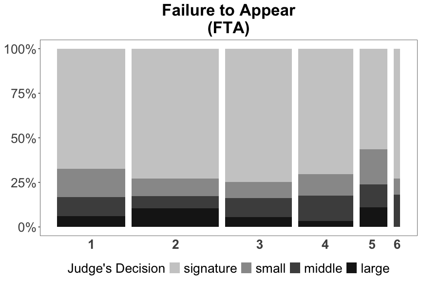

```r
# Call the data
data(psa_synth)
# Treated group (PSA provided)
p.treated <- PlotStackedBar(psa_synth[psa_synth$Z == 1, ],
  d.colors = c("grey80", "grey60", "grey30", "grey10"),
  d.labels = c("signature", "small", "middle", "large"),
  legend.position = "bottom"
)
# Control group (PSA not provided)
p.control <- PlotStackedBar(psa_synth[psa_synth$Z == 0, ],
  d.colors = c("grey80", "grey60", "grey30", "grey10"),
  d.labels = c("signature", "small", "middle", "large"),
  legend.position = "bottom"
)

p.dmf <- PlotStackedBarDMF(psa_synth,
  d.colors = c("grey80", "grey60", "grey30", "grey10"),
  d.labels = c("signature", "small", "middle", "large"),
  dmf.label = "DMF"
)

# For more details
# ?PlotStackedBar

# Example
p.treated$p.fta
```

You may plot the three figures (each for FTA, NCA, and NVCA) together using the codes below.

```r
# To plot three figures together
library(ggplot2)
library(gridExtra)

mylegend <- g_legend(p.control$p.nvca)

# Treated
grid.arrange(
  arrangeGrob(p.control$p.fta + theme(legend.position = "none"),
    p.control$p.nca + theme(legend.position = "none"),
    p.control$p.nvca + theme(legend.position = "none"),
    p.dmf$p.treat + theme(legend.position = "none"),
    nrow = 1
  ),
  mylegend,
  nrow = 2, heights = c(10, 1)
)

# Control
grid.arrange(
  arrangeGrob(p.control$p.fta + theme(legend.position = "none"),
    p.control$p.nca + theme(legend.position = "none"),
    p.control$p.nvca + theme(legend.position = "none"),
    p.dmf$p.control + theme(legend.position = "none"),
    nrow = 1
  ),
  mylegend,
  nrow = 2, heights = c(10, 1)
)
```

#### Replication codes

See the codes that are used to plot Figure 1 and Figure S1-S3 below.

```r
library(aihuman)
data(PSAdata)
library(tidyverse)
library(gridExtra)

# Figure 1
p.treated <- PlotStackedBar(PSAdata %>% filter(Z == 1), legend.position = "bottom")
p.control <- PlotStackedBar(PSAdata %>% filter(Z == 0), legend.position = "bottom")
p.dmf <- PlotStackedBarDMF(PSAdata, dmf.category = c("signature bond", "cash bond"))
mylegend <- g_legend(p.treated$p.nvca)
pdf("figs/stackedbar.pdf", height = 6, width = 22)
grid.arrange(
  arrangeGrob(p.treated$p.fta + theme(legend.position = "none"),
    p.treated$p.nca + theme(legend.position = "none"),
    p.treated$p.nvca + theme(legend.position = "none"),
    p.dmf$p.treat + theme(legend.position = "none"),
    nrow = 1
  ),
  mylegend,
  nrow = 2, heights = c(10, 1)
)
dev.off()
pdf("figs/stackedbar_control.pdf", height = 6, width = 22)
grid.arrange(
  arrangeGrob(p.control$p.fta + theme(legend.position = "none"),
    p.control$p.nca + theme(legend.position = "none"),
    p.control$p.nvca + theme(legend.position = "none"),
    p.dmf$p.control + theme(legend.position = "none"),
    nrow = 1
  ),
  mylegend,
  nrow = 2, heights = c(10, 1)
)
dev.off()

# Figure S1
S0.t <- PlotStackedBar(PSAdata %>% filter(Z == 1 & Sex == 0), legend.position = "bottom")
S0.c <- PlotStackedBar(PSAdata %>% filter(Z == 0 & Sex == 0), legend.position = "bottom")
S0.dmf <- PlotStackedBarDMF(PSAdata %>% filter(Sex == 0),
  dmf.category = c("signature bond", "cash bond")
)
pdf("figs/stackedbar_F.pdf", height = 6, width = 22)
grid.arrange(
  arrangeGrob(S0.t$p.fta + theme(legend.position = "none"),
    S0.t$p.nca + theme(legend.position = "none"),
    S0.t$p.nvca + theme(legend.position = "none"),
    S0.dmf$p.treat + theme(legend.position = "none"),
    nrow = 1
  ),
  mylegend,
  nrow = 2, heights = c(10, 1)
)
dev.off()
pdf("figs/stackedbar_control_F.pdf", height = 6, width = 22)
grid.arrange(
  arrangeGrob(S0.c$p.fta + theme(legend.position = "none"),
    S0.c$p.nca + theme(legend.position = "none"),
    S0.c$p.nvca + theme(legend.position = "none"),
    S0.dmf$p.control + theme(legend.position = "none"),
    nrow = 1
  ),
  mylegend,
  nrow = 2, heights = c(10, 1)
)
dev.off()

# Figure S3
S1W1.t <- PlotStackedBar(PSAdata %>% filter(Z == 1 & Sex == 1 & White == 1), legend.position = "bottom")
S1W1.c <- PlotStackedBar(PSAdata %>% filter(Z == 0 & Sex == 1 & White == 1), legend.position = "bottom")
S1W1.dmf <- PlotStackedBarDMF(PSAdata %>% filter(Sex == 1 & White == 1),
  dmf.category = c("signature bond", "cash bond")
)
pdf("figs/stackedbar_WM.pdf", height = 6, width = 22)
grid.arrange(
  arrangeGrob(S1W1.t$p.fta + theme(legend.position = "none"),
    S1W1.t$p.nca + theme(legend.position = "none"),
    S1W1.t$p.nvca + theme(legend.position = "none"),
    S1W1.dmf$p.treat + theme(legend.position = "none"),
    nrow = 1
  ),
  mylegend,
  nrow = 2, heights = c(10, 1)
)
dev.off()
pdf("figs/stackedbar_control_WM.pdf", height = 6, width = 22)
grid.arrange(
  arrangeGrob(S1W1.c$p.fta + theme(legend.position = "none"),
    S1W1.c$p.nca + theme(legend.position = "none"),
    S1W1.c$p.nvca + theme(legend.position = "none"),
    S1W1.dmf$p.control + theme(legend.position = "none"),
    nrow = 1
  ),
  mylegend,
  nrow = 2, heights = c(10, 1)
)
dev.off()
```

### Intention to treat effects of PSA Provision (Figure 2)

`PlotDIMdecisions()` plots estimated average causal effects of PSA provision on the judge’s decisions and `PlotDIMoutcomes()` plots that on the outcome. The results are based on the difference-in-means estimator. Please check Figure 2 for example. To plot these, you may need to compute the estimates using `CalDIMsubgroup()` function first. This function requires the following main arguments:

- `data`: A `data.frame` of which columns includes a binary treatment (Z), an ordinal decision (D), and an outcome variable (Y) as in `data(synth)`.
- `subgroup`: A list of numeric vectors for the index of each of the five subgroups.

See the example below:

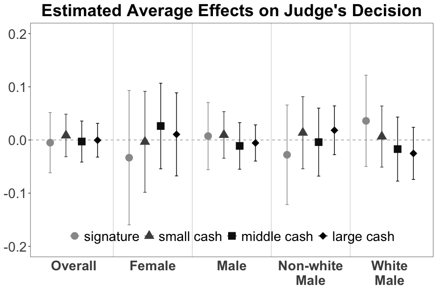

```r
# Call the data
data(synth)

# Subgroup index
subgroup_synth <- list(
  1:nrow(synth),
  which(synth$Sex == 0),
  which(synth$Sex == 1),
  which(synth$Sex == 1 & synth$White == 0),
  which(synth$Sex == 1 & synth$White == 1)
)

# Compute Diff-in-Means on decision
res_dec <- CalDIMsubgroup(synth, subgroup = subgroup_synth)
# Plot the results
PlotDIMdecisions(res_dec,
  decision.labels = c("signature", "small cash", "middle cash", "large cash"),
  col.values = c("grey60", "grey30", "grey6", "grey1"),
  shape.values = c(16, 17, 15, 18)
)
```

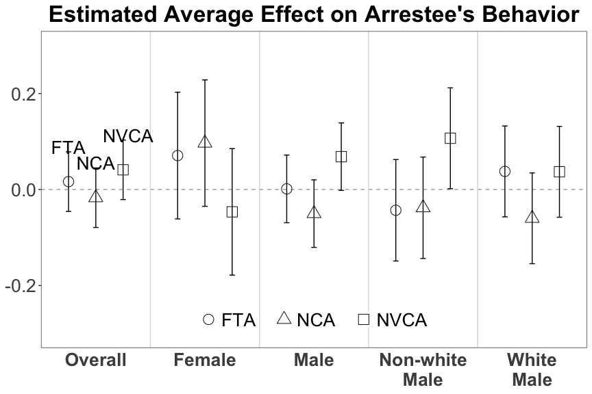

```r
# Synthetic data for outcome
synth_fta <- synth_nca <- synth_nvca <- synth
set.seed(123)
synth_fta$Y <- sample(0:1, 1000, replace = T)
synth_nca$Y <- sample(0:1, 1000, replace = T)
synth_nvca$Y <- sample(0:1, 1000, replace = T)
# Compute Diff-in-Means on outcome
res_fta <- CalDIMsubgroup(synth_fta, subgroup = subgroup_synth)
res_nca <- CalDIMsubgroup(synth_nca, subgroup = subgroup_synth)
res_nvca <- CalDIMsubgroup(synth_nvca, subgroup = subgroup_synth)
# Plot the results
PlotDIMoutcomes(res_fta, res_nca, res_nvca, y.max = 0.3)
```

#### Replication codes

See the codes that are used to plot Figure 2 below.

```r
# Figure 2
data(FTAdata)
data(NCAdata)
data(NVCAdata)

# Subgroup index
subgroup_data <- list(
  1:nrow(FTAdata),
  which(FTAdata$Sex == 0),
  which(FTAdata$Sex == 1),
  which(FTAdata$Sex == 1 & FTAdata$White == 0),
  which(FTAdata$Sex == 1 & FTAdata$White == 1)
)
# Compute Diff-in-Means on decision
res_dec <- CalDIMsubgroup(FTAdata, subgroup = subgroup_data)
# Plot the results
pdf("figs/itt_decisions.pdf", width = 9, height = 5)
PlotDIMdecisions(res_dec, y.max = 0.17)
dev.off()
# Compute Diff-in-Means on outcome
res_fta <- CalDIMsubgroup(FTAdata, subgroup = subgroup_data)
res_nca <- CalDIMsubgroup(NCAdata, subgroup = subgroup_data)
res_nvca <- CalDIMsubgroup(NVCAdata, subgroup = subgroup_data)
# Plot the results
pdf("figs/itt_outcomes.pdf", width = 9, height = 5)
PlotDIMoutcomes(res_fta, res_nca, res_nvca,
  y.max = 0.17, top.margin = 0.02, bottom.margin = 0.02,
  label.position = c("top", "bottom", "top")
)
dev.off()
```

For subgroup analysis for age groups in Figure S5:

```r
# Figure S5
# Subgroup index
subgroup_age <- list(
  which(FTAdata$Age < 23),
  which(FTAdata$Age >= 23 & FTAdata$Age < 29),
  which(FTAdata$Age >= 29 & FTAdata$Age < 36),
  which(FTAdata$Age >= 36 & FTAdata$Age < 46),
  which(FTAdata$Age >= 46)
)
# Compute Diff-in-Means on decision
res_age <- CalDIMsubgroup(FTAdata,
  subgroup = subgroup_age,
  name.group = c("17~22", "23~28", "29~35", "36~45", "46~")
)
# Plot the results
pdf("figs/itt_decisions_age.pdf", width = 9, height = 5)
PlotDIMdecisions(res_age)
dev.off()
# Compute Diff-in-Means on outcome
res_fta_age <- CalDIMsubgroup(FTAdata,
  subgroup = subgroup_age,
  name.group = c("17~22", "23~28", "29~35", "36~45", "46~")
)
res_nca_age <- CalDIMsubgroup(NCAdata,
  subgroup = subgroup_age,
  name.group = c("17~22", "23~28", "29~35", "36~45", "46~")
)
res_nvca_age <- CalDIMsubgroup(NVCAdata,
  subgroup = subgroup_age,
  name.group = c("17~22", "23~28", "29~35", "36~45", "46~")
)
# Plot the results
pdf("figs/itt_outcomes_age.pdf", width = 9, height = 5)
PlotDIMoutcomes(res_fta_age, res_nca_age, res_nvca_age,
  name.group = c("17~22", "23~28", "29~35", "36~45", "46~"),
  top.margin = 0.02, bottom.margin = 0.02,
  label.position = c("top", "bottom", "top")
)
dev.off()
```

## Main analysis: Average Principal Causal Effects (APCE)

To estimate and visualize the APCE using the proposed method, the functions below are used in the following order:

1. `AiEvalmcmc()`: Sample the parameters using Gibbs sampling. See Appendix S5 for more details.
2. `CalAPCE()` or `CalAPCEparallel()`: Compute APCE for each posterior sample from mcmc.
3. `APCEsummary()`: Summarize the results based on the average and 95% quantile of the estimated APCE(s) for each sample from mcmc.
4. `PlotAPCE()`: Visualize the results as in Figure 4.

### `AiEvalmcmc()`

`AiEvalmcmc()` samples the parameters using Gibbs sampler specified in Appendix S5. Basically, you need to specify the data and the number of mcmc iterations (`n.mcmc`).

- `data`: A `data.frame` of which columns consists of pre-treatment covariates, a binary treatment (Z), an ordinal decision (D), and an outcome variable (Y). The column names of the latter three should be specified as “Z”, “D”, and “Y” respectively (e.g., `data(synth)`)
- `n.mcmc`: The total number of MCMC iterations. It should be large enough to guarantee the convergence. You may use Gelman-Rubin statistic for convergence diagnostics. In the paper, we run five Markov chains of 50,000 iterations, retain the second half of each chain and combine them to be used for our analysis. See the replication codes in the later section for more details.

Please check the documentation of the function using the code `?AiEvalmcmc` for other arguments. The example code is as below:

```r
data(synth)
sample_mcmc <- AiEvalmcmc(data = synth, n.mcmc = 10)
```

```
#> 10/10 done.
```

```r
# increase n.mcmc in your analysis
```

### `CalAPCE()` or `CalAPCEparallel()`

`CalAPCE()` computes APCE for each posterior sample in the output of `AiEvalmcmc()`. `CalAPCEparallel()` uses parallel computing to reduce its computation time. You may need three main inputs:

- `data`: The same `data.frame` that is used for `AiEvalmcmc()`.
- `mcmc.re`: The output of `AiEvalmcmc()`.
- `subgroup`: A list of numeric vectors for the index of each of the five subgroups.

For `CalAPCEparallel()`, you also need to specify `size` (the number of parallel computing). I recommend you to check the number of CPU cores in your computer using `parallel::detectCores()` and divide it by 4 to determine the `size`. If the number of CPU cores is 4, use `CalAPCE()` without parallel computing.

Note that the output is in form of `list`. Please check the documentation of the function using the code `?CalAPCE` or `?CalAPCEparallel` for other arguments and the details of outputs. The example code is as below:

```r
subgroup_synth <- list(
  1:nrow(synth),
  which(synth$Sex == 0),
  which(synth$Sex == 1),
  which(synth$Sex == 1 & synth$White == 0),
  which(synth$Sex == 1 & synth$White == 1)
)
sample_apce <- CalAPCE(
  data = synth,
  mcmc.re = sample_mcmc,
  subgroup = subgroup_synth
)
# Or using parallel computing (results are the same):
# sample_apce = CalAPCEparallel(data = synth,
#                               mcmc.re = sample_mcmc,
#                               subgroup = subgroup_synth,
#                               burnin = 0,
#                               size = 2)
```

### `APCEsummary()`

`APCEsummary()` computes the average and 95% quantile of APCE of each sample. You only need the output of `CalAPCE()` or `CalAPCEparallel()`.

```r
sample_apce_summary <- APCEsummary(sample_apce[["APCE.mcmc"]])
```

### `PlotAPCE()` (Figure 4)

`PlotAPCE()` visualizes the results as in Figure 4. See the example below:

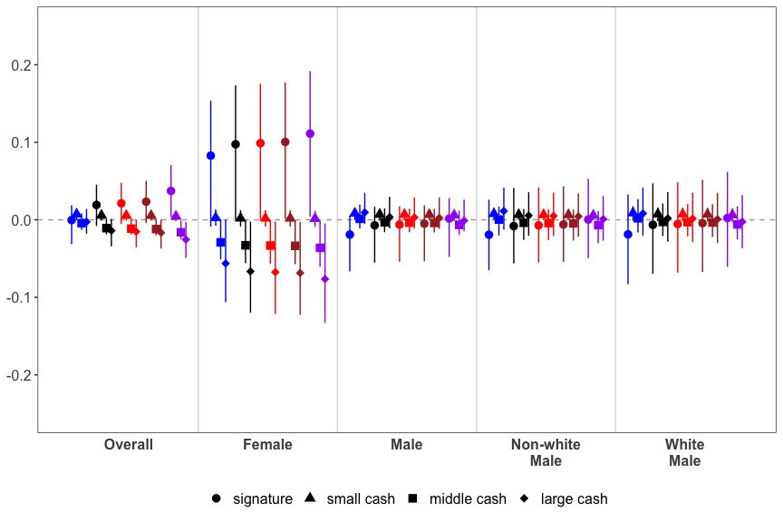

```r
PlotAPCE(sample_apce_summary,
  y.max = 0.25,
  decision.labels = c("signature", "small cash", "middle cash", "large cash"),
  shape.values = c(16, 17, 15, 18),
  col.values = c("blue", "black", "red", "brown", "purple"),
  label = FALSE
)
```

### Replication codes

The codes below is used for the main analysis and the visualization of Figure 4:

```r
## Main analysis
# MCMC
library(coda)
PSADiag_ordinal <- function(data, rho = 0,
                            ## mcmc parameters
                            n.mcmc = 5 * 10^4, verbose = TRUE, out.length = 500) {
  set.seed(111)
  mcmc1 <- AiEvalmcmc(data, rho = rho, n.mcmc = n.mcmc, verbose = TRUE, out.length = out.length)
  set.seed(222)
  mcmc2 <- AiEvalmcmc(data, rho = rho, n.mcmc = n.mcmc, verbose = TRUE, out.length = out.length)
  set.seed(333)
  mcmc3 <- AiEvalmcmc(data, rho = rho, n.mcmc = n.mcmc, verbose = TRUE, out.length = out.length)
  set.seed(444)
  mcmc4 <- AiEvalmcmc(data, rho = rho, n.mcmc = n.mcmc, verbose = TRUE, out.length = out.length)
  set.seed(555)
  mcmc5 <- AiEvalmcmc(data, rho = rho, n.mcmc = n.mcmc, verbose = TRUE, out.length = out.length)

  mcmc.PSA <- mcmc.list(mcmc1, mcmc2, mcmc3, mcmc4, mcmc5)
  return(mcmc.PSA)
}

PSA.ordinal.diag.fta <- PSADiag_ordinal(FTAdata, n.mcmc = 50000, verbose = TRUE, out.length = 500)
PSA.ordinal.diag.nca <- PSADiag_ordinal(NCAdata, n.mcmc = 50000, verbose = TRUE, out.length = 500)
PSA.ordinal.diag.nvca <- PSADiag_ordinal(NVCAdata, n.mcmc = 50000, verbose = TRUE, out.length = 500)

FTAmcmc <- lapply(PSA.ordinal.diag.fta, function(x) x[-(1:floor(0.5 * dim(x)[1])), ])
FTAmcmc <- do.call("rbind", FTAmcmc)
FTAmcmc <- mcmc(FTAmcmc)

NCAmcmc <- lapply(PSA.ordinal.diag.nca, function(x) x[-(1:floor(0.5 * dim(x)[1])), ])
NCAmcmc <- do.call("rbind", NCAmcmc)
NCAmcmc <- mcmc(NCAmcmc)

NVCAmcmc <- lapply(PSA.ordinal.diag.nvca, function(x) x[-(1:floor(0.5 * dim(x)[1])), ])
NVCAmcmc <- do.call("rbind", NVCAmcmc)
NVCAmcmc <- mcmc(NVCAmcmc)

# APCE
subg <- list(
  1:nrow(FTAdata),
  which(FTAdata$Sex == 0),
  which(FTAdata$Sex == 1),
  which(FTAdata$Sex == 1 & FTAdata$White == 0),
  which(FTAdata$Sex == 1 & FTAdata$White == 1)
)

FTAace <- CalAPCEparallel(FTAdata, FTAmcmc, subgroup = subg, rho = 0, burnin = 0, size = 5)
FTAqoi <- APCEsummary(FTAace[["APCE.mcmc"]])

NCAace <- CalAPCEparallel(NCAdata, NCAmcmc, subgroup = subg, rho = 0, burnin = 0, size = 5)
NCAqoi <- APCEsummary(NCAace[["APCE.mcmc"]])

NVCAace <- CalAPCEparallel(NVCAdata, NVCAmcmc, subgroup = subg, rho = 0, burnin = 0, size = 5)
NVCAqoi <- APCEsummary(NVCAace[["APCE.mcmc"]])

# Figure 4
pdf("figs/qoi_fta.pdf", width = 9, height = 3)
PlotAPCE(FTAqoi,
  y.max = 0.166, top.margin = 0.05, bottom.margin = 0.05,
  label.position = c("top", "bottom", "top", "bottom")
) +
  labs(title = "Failure to Appear (FTA)") +
  theme(legend.position = "none")
dev.off()
pdf("figs/qoi_nca.pdf", width = 9, height = 3)
PlotAPCE(NCAqoi, y.max = 0.166, label = FALSE) +
  labs(title = "New Criminal Activity (NCA)") +
  theme(legend.position = "none")
dev.off()
pdf("figs/qoi_nvca.pdf", width = 9, height = 3.5)
PlotAPCE(NVCAqoi, y.max = 0.166, label = FALSE) +
  labs(title = "New Violent Criminal Activity (NVCA)")
dev.off()
```

For subgroup analysis for age groups in Figure S7:

```r
# APCE
subg.age <- list(
  which(FTAdata$Age < 23),
  which(FTAdata$Age >= 23 & FTAdata$Age < 29),
  which(FTAdata$Age >= 29 & FTAdata$Age < 36),
  which(FTAdata$Age >= 36 & FTAdata$Age < 46),
  which(FTAdata$Age >= 46)
)
subg.age.lab <- c("17~22", "23~28", "29~35", "36~45", "46~")
FTAace.age <- CalAPCEparallel(FTAdata, FTAmcmc,
  subgroup = subg.age,
  name.group = subg.age.lab,
  rho = 0, burnin = 0, size = 5
)
FTAqoi.age <- APCEsummary(FTAace.age[["APCE.mcmc"]])

NCAace.age <- CalAPCEparallel(NCAdata, NCAmcmc,
  subgroup = subg.age,
  name.group = subg.age.lab,
  rho = 0, burnin = 0, size = 5
)
NCAqoi.age <- APCEsummary(NCAace.age[["APCE.mcmc"]])

NVCAace.age <- CalAPCEparallel(NVCAdata, NVCAmcmc,
  subgroup = subg.age,
  name.group = subg.age.lab,
  rho = 0, burnin = 0, size = 5
)
NVCAqoi.age <- APCEsummary(NVCAace.age[["APCE.mcmc"]])

# Figure S7
pdf("figs/qoi_fta_age.pdf", width = 9, height = 3)
PlotAPCE(FTAqoi.age,
  y.max = 0.124, top.margin = 0.03, bottom.margin = 0.03,
  label.position = c("top", "bottom", "top", "bottom"),
  name.group = subg.age.lab
) +
  labs(title = "Failure to Appear (FTA)") +
  theme(legend.position = "none")
dev.off()
pdf("figs/qoi_nca_age.pdf", width = 9, height = 3)
PlotAPCE(NCAqoi.age, y.max = 0.124, label = FALSE, name.group = subg.age.lab) +
  labs(title = "New Criminal Activity (NCA)") +
  theme(legend.position = "none")
dev.off()
pdf("figs/qoi_nvca_age.pdf", width = 9, height = 3.5)
PlotAPCE(NVCAqoi.age, y.max = 0.124, label = FALSE, name.group = subg.age.lab) +
  labs(title = "New Violent Criminal Activity (NVCA)")
dev.off()
```

## Principal strata (Figure 3)

Using one of the output (`$P.R.mcmc`) of `CalAPCE()` (or equivalently `CalAPCEparallel()`), `CalPS()` estimates the proportion of each principal stratum ($R_i = 0, \ldots, k+1$) and `PlotPS()` visualizes the results. See section 3.4 for more details about the principal strata in this context.

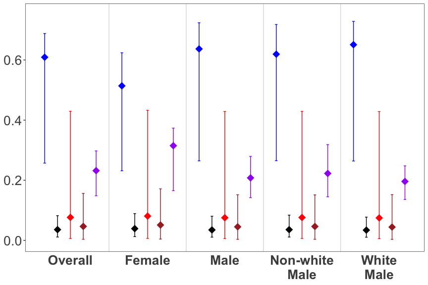

```r
sample_ps <- CalPS(sample_apce$P.R.mcmc)
PlotPS(sample_ps, col.values = c("blue", "black", "red", "brown", "purple"), label = FALSE)
```

### Replication codes

To plot estimated proportion of each principal stratum as in Figure 3:

```r
# P.R
ps_fta <- CalPS(FTAace[["P.R.mcmc"]])
ps_nca <- CalPS(NCAace[["P.R.mcmc"]])
ps_nvca <- CalPS(NVCAace[["P.R.mcmc"]])
# Figure 3
pdf("figs/er_fta.pdf", width = 8, height = 6)
PlotPS(ps_fta, y.max = 1, top.margin = 0.08, label.size = 5.2) +
  labs(title = "Failure to Appear (FTA)")
dev.off()
pdf("figs/er_nca.pdf", width = 8, height = 6)
PlotPS(ps_nca, y.max = 1, top.margin = 0.08, label = FALSE) +
  labs(title = "New Criminal Activity (NCA)")
dev.off()
pdf("figs/er_nvca.pdf", width = 8, height = 6)
PlotPS(ps_nvca, y.max = 1, top.margin = 0.08, label = FALSE) +
  labs(title = "New Violent Criminal Activity (NVCA)")
dev.off()
```

For subgroup analysis for age groups in Figure S7:

```r
# P.R
ps_fta.age <- CalPS(FTAace.age[["P.R.mcmc"]])
ps_nca.age <- CalPS(NCAace.age[["P.R.mcmc"]])
ps_nvca.age <- CalPS(NVCAace.age[["P.R.mcmc"]])
# Figure S7
pdf("figs/er_fta_age.pdf", width = 8, height = 6)
PlotPS(ps_fta.age, y.max = 1, top.margin = 0.08, label.size = 5.2) +
  labs(title = "Failure to Appear (FTA)")
dev.off()
pdf("figs/er_nca_age.pdf", width = 8, height = 6)
PlotPS(ps_nca.age, y.max = 1, top.margin = 0.08, label = FALSE) +
  labs(title = "New Criminal Activity (NCA)")
dev.off()
pdf("figs/er_nvca_age.pdf", width = 8, height = 6)
PlotPS(ps_nvca.age, y.max = 1, top.margin = 0.08, label = FALSE) +
  labs(title = "New Violent Criminal Activity (NVCA)")
dev.off()
```

## Principal fairness (Figure 5)

Using the entire output of `CalAPCE()` (or equivalently `CalAPCEparallel()`), `CalFairness()` computes the principal fairness and `PlotFairness()` visualizes the results. Please check section 3.6 for more details about the measure and see Figure 5 for example. Note that the example below is with $k=3$, whereas the data we used in the paper has $k=2$.

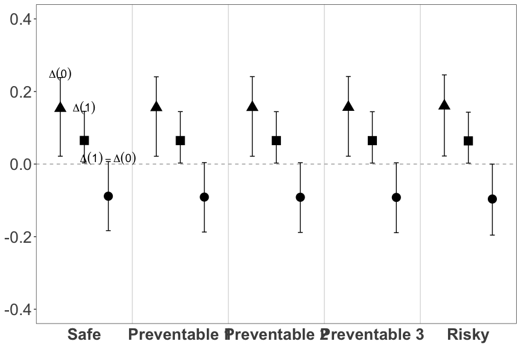

```r
sample_fair <- CalFairness(sample_apce)
PlotFairness(sample_fair, y.max = 0.4, y.min = -0.4, r.labels = c("Safe", "Preventable 1", "Preventable 2", "Preventable 3", "Risky"))
```

### Replication codes

To plot gender and racial fairness in Figure 5:

```r
# Fairness
resfta1 <- CalFairness(FTAace, attr = c(2, 3))
resfta2 <- CalFairness(FTAace, attr = c(4, 5))
resnca1 <- CalFairness(NCAace, attr = c(2, 3))
resnca2 <- CalFairness(NCAace, attr = c(4, 5))
resnvca1 <- CalFairness(NVCAace, attr = c(2, 3))
resnvca2 <- CalFairness(NVCAace, attr = c(4, 5))

# Figure S5
p1 <- PlotFairness(resfta1, top.margin = 0.02, y.max = 0.3) +
  labs(title = "Failure to Appear (FTA)") + ylab("maximal sungroup difference")
p4 <- PlotFairness(resfta2, top.margin = 0.02, y.max = 0.3) +
  labs(title = "Failure to Appear (FTA)") + ylab("maximal sungroup difference")
p2 <- PlotFairness(resnca1, top.margin = 0.02, y.max = 0.3, label = F) +
  labs(title = "New Criminal Activity (NCA)")
p5 <- PlotFairness(resnca2, top.margin = 0.02, y.max = 0.3, label = F) +
  labs(title = "New Criminal Activity (NCA)")
p3 <- PlotFairness(resnvca1, top.margin = 0.02, y.max = 0.3, label = F) +
  labs(title = "New Violent Criminal Activity (NVCA)")
p6 <- PlotFairness(resnvca2, top.margin = 0.02, y.max = 0.3, label = F) +
  labs(title = "New Violent Criminal Activity (NVCA)")

pdf("figs/fair_gender.pdf", height = 5, width = 24)
cowplot::plot_grid(p1, p2, p3, nrow = 1)
dev.off()

pdf("figs/fair_race.pdf", height = 5, width = 24)
cowplot::plot_grid(p4, p5, p6, nrow = 1)
dev.off()
```

## Optimal decision (Figure 6)

`CalOptimalDecision()` conducts the following:

1. Calculate optimal decision for each observation given each of $c_0$ (cost of an outcome) and $c_1$ (cost of an unnecessarily harsh decision) from the lists.
2. Calculate difference in the expected utility between binary version of judge’s decisions and DMF recommendations given each of $c_0$ and $c_1$ from the lists.

Note that the second component is used for the comparison between the judge’s decisions and DMF recommendations explained in the following section. The main inputs are as follows:

- `data`: The same `data.frame` that is used for `AiEvalmcmc()`.
- `mcmc.re`: The output of `AiEvalmcmc()`.
- `c0.ls`: The list of possible cost of an outcome.
- `c1.ls`: The list of possible cost of an unnecessarily harsh decision.

You may also specify `size`, the number of parallel computing, based on the number of CPU cores. Also, if `include.utility.diff.mcmc = TRUE`, it would include `Utility.diff.control.mcmc` and `Utility.diff.treated.mcmc` in the output which is needed for the inference as in Figure S17. Please check the details with `?CalOptimalDecision` before the analysis. Using the outputs of this function, we can visualize the results (estimated proportion of cases for which specific decision is optimal) by `PlotOptimalDecision()` as in Figure 6. The input is as follows:

- If `include.utility.diff.mcmc = FALSE`, use the entire output of `CalOptimalDecision()`.
- If `include.utility.diff.mcmc = TRUE`, use output`$res.i`.

Please check Section 3.7 and 4.4 for more details about the inference.

```r
# ?CalOptimalDecision # Please check the details
synth_dmf <- sample(0:1, nrow(synth), replace = TRUE) # random dmf recommendation
sample_optd_ci <- CalOptimalDecision(
  data = synth,
  mcmc.re = sample_mcmc,
  c0.ls = seq(0, 5, 1), c1.ls = seq(0, 5, 1),
  dmf = synth_dmf,
  include.utility.diff.mcmc = TRUE,
  # because of the above argument, the output is now a list
  size = 2
)
sample_optd <- sample_optd_ci$res.i
# Suppose we want to plot the proportion of cases for which *cash bond*
# (either d1, d2 or d3) is optimal
sample_optd$cash <- sample_optd$d1 + sample_optd$d2 + sample_optd$d3
# Specify the column name of decision to be plotted, which is "cash" in this case.
PlotOptimalDecision(sample_optd, "cash")
```

### Replication codes

To plot estimated proportion of cases for which cash bond is optimal as in Figure 6 (and Figure S16):

```r
# Optimal Decision
optd_fta_ci <- CalOptimalDecision(
  data = FTAdata, mcmc.re = FTAmcmc,
  c0.ls = seq(0, 10, 0.5), c1.ls = seq(0, 3, 0.1),
  dmf = PSAdata$DMF, size = 5,
  include.utility.diff.mcmc = TRUE
)
optd_nca_ci <- CalOptimalDecision(
  data = NCAdata, mcmc.re = NCAmcmc,
  c0.ls = seq(0, 10, 0.5), c1.ls = seq(0, 3, 0.1),
  dmf = PSAdata$DMF, size = 5,
  include.utility.diff.mcmc = TRUE
)
optd_nvca_ci <- CalOptimalDecision(
  data = NVCAdata, mcmc.re = NVCAmcmc,
  c0.ls = seq(0, 10, 0.5), c1.ls = seq(0, 3, 0.1),
  dmf = PSAdata$DMF, size = 5,
  include.utility.diff.mcmc = TRUE
)
optd_fta <- optd_fta_ci$res.i
optd_nca <- optd_nca_ci$res.i
optd_nvca <- optd_nvca_ci$res.i
optd_fta$cash <- optd_fta$d1 + optd_fta$d2
optd_nca$cash <- optd_nca$d1 + optd_nca$d2
optd_nvca$cash <- optd_nvca$d1 + optd_nvca$d2

# Figure 6
p1 <- PlotOptimalDecision(res = optd_fta, colname.d = "cash", idx = which(PSAdata$DMF == 0)) +
  labs(
    title = "Failure to Appear (FTA)", x = expression("Cost of FTA (" * c[0] * ")"),
    y = expression("Cost of unnecessarily harsh decision (" * c[1] * ")")
  )
p2 <- PlotOptimalDecision(res = optd_nca, colname.d = "cash", idx = which(PSAdata$DMF == 0)) +
  labs(title = "New Criminal Activity (NCA)", x = expression("Cost of NCA (" * c[0] * ")"), y = NULL)
p3 <- PlotOptimalDecision(
  res = optd_nvca, colname.d = "cash", idx = which(PSAdata$DMF == 0),
  label.place = label_placement_fraction(0.9)
) +
  labs(
    title = "New Violent Criminal Activity (NVCA)",
    x = expression("Cost of NVCA (" * c[0] * ")"), y = NULL
  )
p4 <- PlotOptimalDecision(res = optd_fta, colname.d = "cash", idx = which(PSAdata$DMF == 1)) +
  labs(
    x = expression("Cost of FTA (" * c[0] * ")"),
    y = expression("Cost of unnecessarily harsh decision (" * c[1] * ")")
  )
p5 <- PlotOptimalDecision(res = optd_nca, colname.d = "cash", idx = which(PSAdata$DMF == 1)) +
  labs(x = expression("Cost of NCA (" * c[0] * ")"), y = NULL)
p6 <- PlotOptimalDecision(
  res = optd_nvca, colname.d = "cash", idx = which(PSAdata$DMF == 1),
  label.place = label_placement_fraction(0.9)
) +
  labs(x = expression("Cost of NVCA (" * c[0] * ")"), y = NULL)


pdf("figs/optd_combined_signature.pdf", width = 16, height = 5.2)
cowplot::plot_grid(p1, p2, p3, nrow = 1)
dev.off()

pdf("figs/optd_combined_cash.pdf", width = 16, height = 5.2)
cowplot::plot_grid(p4, p5, p6, nrow = 1)
dev.off()

# Figure S16
p1 <- PlotOptimalDecision(res = optd_fta, colname.d = "cash", idx = which(PSAdata$FTAScore <= 4)) +
  labs(
    title = "Failure to Appear (FTA)", subtitle = "FTA Score: 1 - 4",
    x = expression("Cost of FTA (" * c[0] * ")"),
    y = expression("Cost of unnecessarily harsh decision (" * c[1] * ")")
  )
p2 <- PlotOptimalDecision(res = optd_nca, colname.d = "cash", idx = which(PSAdata$NCAScore <= 4)) +
  labs(
    title = "New Criminal Activity (NCA)", subtitle = "NCA Score: 1 - 4",
    x = "NCA Score: 1 - 4", y = NULL
  )
p3 <- PlotOptimalDecision(
  res = optd_nvca, colname.d = "cash", idx = which(PSAdata$NVCAFlag == 0),
  label.place = label_placement_fraction(0.9)
) +
  labs(
    title = "New Violent Criminal Activity (NVCA)", subtitle = "NVCA Flag: 0",
    x = expression("Cost of NVCA (" * c[0] * ")"), y = NULL
  )
p4 <- PlotOptimalDecision(res = optd_fta, colname.d = "cash", idx = which(PSAdata$FTAScore > 4)) +
  labs(
    subtitle = "FTA Score: 5 - 6", x = expression("Cost of FTA (" * c[0] * ")"),
    y = expression("Cost of unnecessarily harsh decision (" * c[1] * ")")
  )
p5 <- PlotOptimalDecision(res = optd_nca, colname.d = "cash", idx = which(PSAdata$NCAScore > 4)) +
  labs(subtitle = "NCA Score: 5 - 6", x = expression("Cost of NCA (" * c[0] * ")"), y = NULL)
p6 <- PlotOptimalDecision(
  res = optd_nvca, colname.d = "cash", idx = which(PSAdata$NVCAFlag == 1),
  label.place = label_placement_fraction(0.9)
) +
  labs(subtitle = "NVCA Flag: 1", x = expression("Cost of NVCA (" * c[0] * ")"), y = NULL)


pdf("figs/optd_separate_signature.pdf", width = 16, height = 5.2)
cowplot::plot_grid(p1, p2, p3, nrow = 1)
dev.off()

pdf("figs/optd_separate_cash.pdf", width = 16, height = 5.2)
cowplot::plot_grid(p4, p5, p6, nrow = 1)
dev.off()
```

## Comparison between the judge’s decisions and DMF recommendations (Figure 7)

Using the output of `CalOptimalDecision()`, we can compare the judge’s decisions and DMF recommendations. See Section 4.5 for more details. `PlotUtilityDiff()` visualizes the estimated difference in the expected utility between judge’s decisions and DMF Recommendations (e.g., Figure 7). Additionally, `PlotUtilityDiffCI()` plot the estimated difference with 95% confidence interval (e.g., Figure S17).

```r
PlotUtilityDiff(sample_optd_ci$res.i)
PlotUtilityDiffCI(sample_optd_ci$res.mcmc)
```

### Replication codes

Codes for Figure 7 and Figure S17:

```r
# Figure 7
p1 <- PlotUtilityDiff(optd_fta, which(PSAdata$Z == 1)) +
  labs(
    title = "Failure to Appear (FTA)",
    x = expression("Cost of FTA (" * c[0] * ")"),
    y = expression("Cost of unnecessarily harsh decision (" * c[1] * ")")
  )
p2 <- PlotUtilityDiff(optd_nca, which(PSAdata$Z == 1)) +
  labs(
    title = "New Criminal Activity (NCA)",
    x = expression("Cost of NCA (" * c[0] * ")"), y = NULL
  )
p3 <- PlotUtilityDiff(optd_nvca, which(PSAdata$Z == 1)) +
  labs(
    title = "New Violent Criminal Activity (NVCA)",
    x = expression("Cost of NVCA (" * c[0] * ")"), y = NULL
  )
p4 <- PlotUtilityDiff(optd_fta, which(PSAdata$Z == 0)) +
  labs(
    x = expression("Cost of FTA (" * c[0] * ")"),
    y = expression("Cost of unnecessarily harsh decision (" * c[1] * ")")
  )
p5 <- PlotUtilityDiff(optd_nca, which(PSAdata$Z == 0)) +
  labs(x = expression("Cost of NCA (" * c[0] * ")"), y = NULL)
p6 <- PlotUtilityDiff(optd_nvca, which(PSAdata$Z == 0)) +
  labs(x = expression("Cost of NVCA (" * c[0] * ")"), y = NULL)

pdf("figs/utility_treatment.pdf", width = 16, height = 5.2)
cowplot::plot_grid(p1, p2, p3, nrow = 1)
dev.off()

pdf("figs/utility_control.pdf", width = 16, height = 5.2)
cowplot::plot_grid(p4, p5, p6, nrow = 1)
dev.off()

# Figure S17
p.fta <- PlotUtilityDiffCI(optd_fta_ci$res.mcmc)
p.nca <- PlotUtilityDiffCI(optd_nca_ci$res.mcmc)
p.nvca <- PlotUtilityDiffCI(optd_nvca_ci$res.mcmc)
p1 <- p.fta$p.treated + labs(
  title = "Failure to Appear (FTA)",
  y = "Difference in the Expected Utility",
  x = expression("Cost of FTA (" * c[0] * ")")
)
p2 <- p.nca$p.treated + labs(
  title = "New Criminal Activity (NCA)",
  y = "Difference in the Expected Utility",
  x = expression("Cost of NCA (" * c[0] * ")")
)
p3 <- p.nvca$p.treated + labs(
  title = "New Violent Criminal Activity (NVCA)",
  y = "Difference in the Expected Utility",
  x = expression("Cost of NVCA (" * c[0] * ")")
)
p4 <- p.fta$p.control + labs(
  title = "Failure to Appear (FTA)",
  y = "Difference in the Expected Utility",
  x = expression("Cost of FTA (" * c[0] * ")")
)
p5 <- p.nca$p.control + labs(
  title = "New Criminal Activity (NCA)",
  y = "Difference in the Expected Utility",
  x = expression("Cost of NCA (" * c[0] * ")")
)
p6 <- p.nvca$p.control + labs(
  title = "New Violent Criminal Activity (NVCA)",
  y = "Difference in the Expected Utility",
  x = expression("Cost of NVCA (" * c[0] * ")")
)

pdf("figs/utility_treat_ci.pdf", width = 18, height = 6)
cowplot::plot_grid(p1, p2, p3, nrow = 1)
dev.off()

pdf("figs/utility_control_ci.pdf", width = 18, height = 6)
cowplot::plot_grid(p4, p5, p6, nrow = 1)
dev.off()
```

## Test of spillover effects: Conditional Randomization Test (CRT)

In Appendix S3, we examine the possible existence of spillover effects using CRT. `SpilloverCRT()` conducts CRT based on court hearing date and additionally `SpilloverCRTpower()` conduct power analysis of the test using simulation. The result can be visualized using `PlotSpilloverCRT()` and `PlotSpilloverCRTpower()`. See the example below.

```r
# CRT
data(hearingdate_synth)
crt <- SpilloverCRT(
  D = synth$D,
  Z = synth$Z,
  CourtEvent_HearingDate = hearingdate_synth,
  n = 100
) # increase the permutation size to 10000
PlotSpilloverCRT(crt)

# Power analysis
crt_power <- SpilloverCRTpower(
  D = synth$D,
  Z = synth$Z,
  CourtEvent_HearingDate = hearingdate_synth
)
PlotSpilloverCRTpower(crt_power)
```

### Replication codes

Codes for Figure S8 and Figure S9:

```r
data(HearingDate)
crt_data <- data.frame(
  D = FTAdata$D,
  Z = FTAdata$Z,
  CourtEvent_HearingDate = HearingDate
)
# CRT
crt <- SpilloverCRT(
  D = crt_data$D,
  Z = crt_data$Z,
  CourtEvent_HearingDate = crt_data$CourtEvent_HearingDate,
  n = 10000
)
# Figure S8
pdf("figs/hist_crt.pdf", width = 4, height = 6)
PlotSpilloverCRT(crt)
dev.off()

# Power analysis
crt_power <- SpilloverCRTpower(
  D = crt_data$D,
  Z = crt_data$Z,
  CourtEvent_HearingDate = crt_data$CourtEvent_HearingDate,
  size = 5,
  n = 1000,
  m = 1000,
  cand_omegaZtilde = seq(-1.5, 1.5, by = 0.5)
)
# Figure S9
pdf("figs/crt_power_prop.pdf", width = 4, height = 6)
PlotSpilloverCRTpower(crt_power)
dev.off()
```

## Frequentist analysis

In Appendix S7, we implement frequentist analysis and present the results. This can be done by `CalAPCEipw()`. Additionally, you may have to run `BootstrapAPCEipw()` for the confidence interval. Note that you should run `CalAPCEipw()` for each of subgroups, and make sure to drop the column that is constant across a specific subgroup (e.g., `Sex` column for the subset of Female arrestees). The result can be summarized with `APCEsummaryipw()` and visualized by `PlotAPCE()` as before.

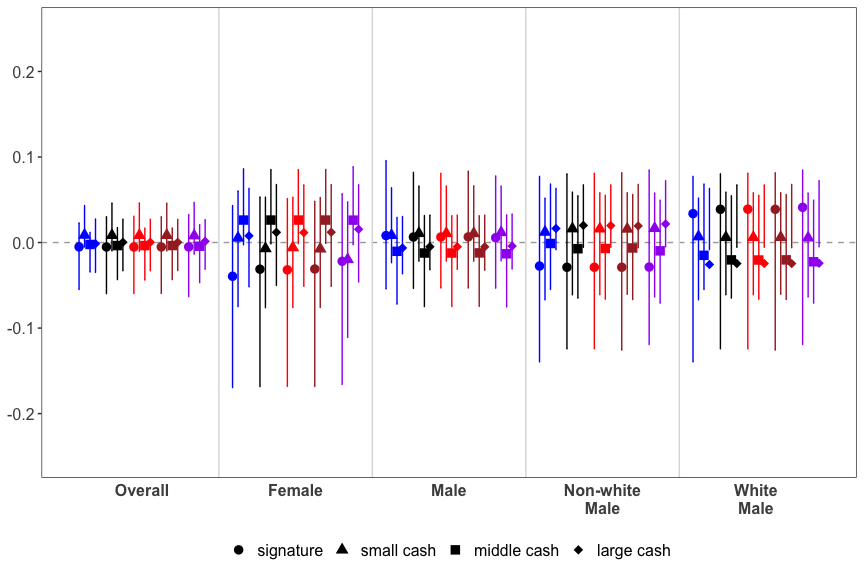

```r
synth$SexWhite <- synth$Sex * synth$White
freq_apce <- CalAPCEipw(synth)
boot_apce <- BootstrapAPCEipw(synth, rep = 10)
# subgroup analysis
data_s0 <- subset(synth, synth$Sex == 0, select = -c(Sex, SexWhite))
freq_s0 <- CalAPCEipw(data_s0)
boot_s0 <- BootstrapAPCEipw(data_s0, rep = 10)
data_s1 <- subset(synth, synth$Sex == 1, select = -c(Sex, SexWhite))
freq_s1 <- CalAPCEipw(data_s1)
boot_s1 <- BootstrapAPCEipw(data_s1, rep = 10)
data_s1w0 <- subset(synth, synth$Sex == 1 & synth$White == 0, select = -c(Sex, White, SexWhite))
freq_s1w0 <- CalAPCEipw(data_s1w0)
boot_s1w0 <- BootstrapAPCEipw(data_s1w0, rep = 10)
data_s1w1 <- subset(synth, synth$Sex == 1 & synth$White == 1, select = -c(Sex, White, SexWhite))
freq_s1w1 <- CalAPCEipw(data_s1w1)
boot_s1w1 <- BootstrapAPCEipw(data_s1w1, rep = 10)

freq_apce_summary <- APCEsummaryipw(
  freq_apce, freq_s0, freq_s1,
  freq_s1w0, freq_s1w1,
  boot_apce, boot_s0, boot_s1,
  boot_s1w0, boot_s1w0
)
PlotAPCE(freq_apce_summary,
  y.max = 0.25,
  decision.labels = c("signature", "small cash", "middle cash", "large cash"),
  shape.values = c(16, 17, 15, 18),
  col.values = c("blue", "black", "red", "brown", "purple"), label = FALSE
)
```

We also fit the model including random effects for the hearing date of the case in the paper. This can be done with `CalAPCEipwRE()` and `BootstrapAPCEipwRE()`/`BootstrapAPCEipwREparallel()`. You may need to specify the precise formula of the model in this case.

### Replication codes

Codes for Figure S10, S11, and S12.

```r
set.seed(123) # seed for bootstrap
## Frequentist approach
# FTA
freq_apce <- CalAPCEipw(FTAdata)
boot_apce <- BootstrapAPCEipw(FTAdata, rep = 1000)
data_s0 <- subset(FTAdata, FTAdata$Sex == 0, select = -c(Sex, SexWhite))
freq_s0 <- CalAPCEipw(data_s0)
boot_s0 <- BootstrapAPCEipw(data_s0, rep = 1000)
data_s1 <- subset(FTAdata, FTAdata$Sex == 1, select = -c(Sex, SexWhite))
freq_s1 <- CalAPCEipw(data_s1)
boot_s1 <- BootstrapAPCEipw(data_s1, rep = 1000)
data_s1w0 <- subset(FTAdata, FTAdata$Sex == 1 & FTAdata$White == 0, select = -c(Sex, White, SexWhite))
freq_s1w0 <- CalAPCEipw(data_s1w0)
boot_s1w0 <- BootstrapAPCEipw(data_s1w0, rep = 1000)
data_s1w1 <- subset(FTAdata, FTAdata$Sex == 1 & FTAdata$White == 1, select = -c(Sex, White, SexWhite))
freq_s1w1 <- CalAPCEipw(data_s1w1)
boot_s1w1 <- BootstrapAPCEipw(data_s1w1, rep = 1000)
fta_apce_summary <- APCEsummaryipw(
  freq_apce, freq_s0, freq_s1,
  freq_s1w0, freq_s1w1,
  boot_apce, boot_s0, boot_s1,
  boot_s1w0, boot_s1w0
)
# NCA
freq_apce <- CalAPCEipw(NCAdata)
boot_apce <- BootstrapAPCEipw(NCAdata, rep = 1000)
data_s0 <- subset(NCAdata, NCAdata$Sex == 0, select = -c(Sex, SexWhite))
freq_s0 <- CalAPCEipw(data_s0)
boot_s0 <- BootstrapAPCEipw(data_s0, rep = 1000)
data_s1 <- subset(NCAdata, NCAdata$Sex == 1, select = -c(Sex, SexWhite))
freq_s1 <- CalAPCEipw(data_s1)
boot_s1 <- BootstrapAPCEipw(data_s1, rep = 1000)
data_s1w0 <- subset(NCAdata, NCAdata$Sex == 1 & NCAdata$White == 0, select = -c(Sex, White, SexWhite))
freq_s1w0 <- CalAPCEipw(data_s1w0)
boot_s1w0 <- BootstrapAPCEipw(data_s1w0, rep = 1000)
data_s1w1 <- subset(NCAdata, NCAdata$Sex == 1 & NCAdata$White == 1, select = -c(Sex, White, SexWhite))
freq_s1w1 <- CalAPCEipw(data_s1w1)
boot_s1w1 <- BootstrapAPCEipw(data_s1w1, rep = 1000)
nca_apce_summary <- APCEsummaryipw(
  freq_apce, freq_s0, freq_s1,
  freq_s1w0, freq_s1w1,
  boot_apce, boot_s0, boot_s1,
  boot_s1w0, boot_s1w0
)

# Figure S10
pdf("figs/qoi_fta_freq.pdf", width = 9, height = 3)
PlotAPCE(fta_freq_apce_summary,
  y.max = 0.23, top.margin = 0.05, bottom.margin = 0.05,
  label.position = c("top", "bottom", "top", "bottom")
) +
  labs(title = "Failure to Appear (FTA)") +
  theme(legend.position = "none")
dev.off()
pdf("figs/qoi_nca_freq.pdf", width = 9, height = 3.5)
PlotAPCE(nca_freq_apce_summary, y.max = 0.23, label = FALSE) +
  labs(title = "New Criminal Activity (NCA)")
dev.off()

## Random effects
full.demographics <- "Sex + White + SexWhite + Age"
full.other.cov <- "PendingChargeAtTimeOfOffense + NCorNonViolentMisdemeanorCharge + ViolentMisdemeanorCharge + ViolentFelonyCharge + NonViolentFelonyCharge + PriorMisdemeanorConviction + PriorFelonyConviction + PriorViolentConviction + PriorSentenceToIncarceration + PriorFTAInPast2Years + PriorFTAOlderThan2Years + Staff_ReleaseRecommendation + D"

mod <- paste0("Y ~ ", full.demographics, " + ", full.other.cov)
mod.s <- paste0("Y ~ White + Age + ", full.other.cov)
mod.sw <- paste0("Y ~ Age + ", full.other.cov)

re.mod <- "~ 1|CourtEvent_HearingDate"

# FTA
freq_apce <- CalAPCEipwRE(FTAdata, fixed = mod, random = re.mod)
boot_apce <- BootstrapAPCEipwRE(FTAdata, rep = 1000, fixed = mod, random = re.mod)
data_s0 <- subset(FTAdata, FTAdata$Sex == 0, select = -c(Sex, SexWhite))
freq_s0 <- CalAPCEipwRE(data_s0, fixed = mod.s, random = re.mod)
boot_s0 <- BootstrapAPCEipwRE(data_s0, rep = 1000, fixed = mod.s, random = re.mod)
data_s1 <- subset(FTAdata, FTAdata$Sex == 1, select = -c(Sex, SexWhite))
freq_s1 <- CalAPCEipwRE(data_s1, fixed = mod.s, random = re.mod)
boot_s1 <- BootstrapAPCEipwRE(data_s1, rep = 1000, fixed = mod.s, random = re.mod)
data_s1w0 <- subset(FTAdata, FTAdata$Sex == 1 & FTAdata$White == 0, select = -c(Sex, White, SexWhite))
freq_s1w0 <- CalAPCEipwRE(data_s1w0, fixed = mod.sw, random = re.mod)
boot_s1w0 <- BootstrapAPCEipwRE(data_s1w0, rep = 1000, fixed = mod.sw, random = re.mod)
data_s1w1 <- subset(FTAdata, FTAdata$Sex == 1 & FTAdata$White == 1, select = -c(Sex, White, SexWhite))
freq_s1w1 <- CalAPCEipwRE(data_s1w1, fixed = mod.sw, random = re.mod)
boot_s1w1 <- BootstrapAPCEipwRE(data_s1w1, rep = 1000, fixed = mod.sw, random = re.mod)
fta_re_apce_summary <- APCEsummaryipw(
  freq_apce, freq_s0, freq_s1,
  freq_s1w0, freq_s1w1,
  boot_apce, boot_s0, boot_s1,
  boot_s1w0, boot_s1w0
)
# NCA
freq_apce <- CalAPCEipwRE(NCAdata, fixed = mod, random = re.mod)
boot_apce <- BootstrapAPCEipwRE(NCAdata, rep = 1000, fixed = mod, random = re.mod)
data_s0 <- subset(NCAdata, NCAdata$Sex == 0, select = -c(Sex, SexWhite))
freq_s0 <- CalAPCEipwRE(data_s0, fixed = mod.s, random = re.mod)
boot_s0 <- BootstrapAPCEipwRE(data_s0, rep = 1000, fixed = mod.s, random = re.mod)
data_s1 <- subset(NCAdata, NCAdata$Sex == 1, select = -c(Sex, SexWhite))
freq_s1 <- CalAPCEipwRE(data_s1, fixed = mod.s, random = re.mod)
boot_s1 <- BootstrapAPCEipwRE(data_s1, rep = 1000, fixed = mod.s, random = re.mod)
data_s1w0 <- subset(NCAdata, NCAdata$Sex == 1 & NCAdata$White == 0, select = -c(Sex, White, SexWhite))
freq_s1w0 <- CalAPCEipwRE(data_s1w0, fixed = mod.sw, random = re.mod)
boot_s1w0 <- BootstrapAPCEipwRE(data_s1w0, rep = 1000, fixed = mod.sw, random = re.mod)
data_s1w1 <- subset(NCAdata, NCAdata$Sex == 1 & NCAdata$White == 1, select = -c(Sex, White, SexWhite))
freq_s1w1 <- CalAPCEipwRE(data_s1w1, fixed = mod.sw, random = re.mod)
boot_s1w1 <- BootstrapAPCEipwRE(data_s1w1, rep = 1000, fixed = mod.sw, random = re.mod)
nca_re_apce_summary <- APCEsummaryipw(
  freq_apce, freq_s0, freq_s1,
  freq_s1w0, freq_s1w1,
  boot_apce, boot_s0, boot_s1,
  boot_s1w0, boot_s1w0
)

# Figure S11
pdf("figs/qoi_fta_freq_re.pdf", width = 9, height = 3)
PlotAPCE(fta_freq_apce_summary,
  y.max = 0.34, top.margin = 0.1, bottom.margin = 0.1,
  label.position = c("top", "bottom", "top", "bottom")
) +
  labs(title = "Failure to Appear (FTA)") +
  theme(legend.position = "none")
dev.off()
pdf("figs/qoi_nca_freq_re.pdf", width = 9, height = 3.5)
PlotAPCE(nca_freq_apce_summary, y.max = 0.34, label = FALSE) +
  labs(title = "New Criminal Activity (NCA)")
dev.off()

## Age subgroup
# FTA
data_age1 <- subset(FTAdata, FTAdata$Age <= 22)
freq_age1 <- CalAPCEipw(data_age1)
boot_age1 <- BootstrapAPCEipw(data_age1, rep = 1000)
data_age2 <- subset(FTAdata, FTAdata$Age > 22 & FTAdata$Age <= 28)
freq_age2 <- CalAPCEipw(data_age2)
boot_age2 <- BootstrapAPCEipw(data_age2, rep = 1000)
data_age3 <- subset(FTAdata, FTAdata$Age > 28 & FTAdata$Age <= 35)
freq_age3 <- CalAPCEipw(data_age3)
boot_age3 <- BootstrapAPCEipw(data_age3, rep = 1000)
data_age4 <- subset(FTAdata, FTAdata$Age > 35 & FTAdata$Age <= 45)
freq_age4 <- CalAPCEipw(data_age4)
boot_age4 <- BootstrapAPCEipw(data_age4, rep = 1000)
data_age5 <- subset(FTAdata, FTAdata$Age > 45)
freq_age5 <- CalAPCEipw(data_age5)
boot_age5 <- BootstrapAPCEipw(data_age5, rep = 1000)
fta_apce_summary <- APCEsummaryipw(
  freq_age1, freq_age2, freq_age3,
  freq_age4, freq_age5,
  boot_age1, boot_age2, boot_age3,
  boot_age4, boot_age5
)
# NCA
data_age1 <- subset(NCAdata, NCAdata$Age <= 22)
freq_age1 <- CalAPCEipw(data_age1)
boot_age1 <- BootstrapAPCEipw(data_age1, rep = 1000)
data_age2 <- subset(NCAdata, NCAdata$Age > 22 & NCAdata$Age <= 28)
freq_age2 <- CalAPCEipw(data_age2)
boot_age2 <- BootstrapAPCEipw(data_age2, rep = 1000)
data_age3 <- subset(NCAdata, NCAdata$Age > 28 & NCAdata$Age <= 35)
freq_age3 <- CalAPCEipw(data_age3)
boot_age3 <- BootstrapAPCEipw(data_age3, rep = 1000)
data_age4 <- subset(NCAdata, NCAdata$Age > 35 & NCAdata$Age <= 45)
freq_age4 <- CalAPCEipw(data_age4)
boot_age4 <- BootstrapAPCEipw(data_age4, rep = 1000)
data_age5 <- subset(NCAdata, NCAdata$Age > 45)
freq_age5 <- CalAPCEipw(data_age5)
boot_age5 <- BootstrapAPCEipw(data_age5, rep = 1000)
fta_apce_summary <- APCEsummaryipw(
  freq_age1, freq_age2, freq_age3,
  freq_age4, freq_age5,
  boot_age1, boot_age2, boot_age3,
  boot_age4, boot_age5
)
# Figure S12
pdf("figs/qoi_fta_freq_age.pdf", width = 9, height = 3)
PlotAPCE(fta_freq_apce_summary,
  y.max = 0.25, top.margin = 0.13, bottom.margin = 0.09,
  label.position = c("top", "bottom", "top", "bottom"),
  name.group = c("17~22", "23~28", "29~35", "36~45", "46~")
) +
  labs(title = "Failure to Appear (FTA)") +
  theme(legend.position = "none")
dev.off()
pdf("figs/qoi_nca_freq_age.pdf", width = 9, height = 3.5)
PlotAPCE(nca_freq_apce_summary,
  y.max = 0.25, label = FALSE,
  name.group = c("17~22", "23~28", "29~35", "36~45", "46~")
) +
  labs(title = "New Criminal Activity (NCA)")
dev.off()
```

## Sensitivity analysis

As discussed in Section 3.5, we conduct sensitivity analysis of the unconfoundedness assumption, which may be violated when researchers do not observe some information that is used by the judge and is predictive of arrestees’ behavior. Parametric sensitivity analysis can be done by setting non-zero `rho`, the sensitivity parameter, for `AiEvalmcmc()` and `CalAPCE()`/`CalAPCEparallel()`.

### Replication codes

Codes for Figure S13, S14, and S15.

```r
## rho = 0.05
## Main analysis
# MCMC
FTAmcmc <- AiEvalmcmc(FTAdata, rho = 0.05, n.mcmc = 60000, verbose = TRUE, out.length = 500)
NCAmcmc <- AiEvalmcmc(NCAdata, rho = 0.05, n.mcmc = 60000, verbose = TRUE, out.length = 500)
NVCAmcmc <- AiEvalmcmc(NVCAdata, rho = 0.05, n.mcmc = 60000, verbose = TRUE, out.length = 500)

# APCE
FTAace <- CalAPCEparallel(FTAdata, FTAmcmc, subgroup = subg, rho = 0.05, burnin = 2 / 3, size = 5)
FTAqoi <- APCEsummary(FTAace[["APCE.mcmc"]])

NCAace <- CalAPCEparallel(NCAdata, NCAmcmc, subgroup = subg, rho = 0.05, burnin = 2 / 3, size = 5)
NCAqoi <- APCEsummary(NCAace[["APCE.mcmc"]])

NVCAace <- CalAPCEparallel(NVCAdata, NVCAmcmc, subgroup = subg, rho = 0.05, burnin = 2 / 3, size = 5)
NVCAqoi <- APCEsummary(NVCAace[["APCE.mcmc"]])

# Figure S13
pdf("figs/sens_fta_005.pdf", width = 9, height = 3)
PlotAPCE(FTAqoi,
  y.max = 0.18, top.margin = 0.05, bottom.margin = 0.05,
  label.position = c("top", "bottom", "top", "bottom")
) +
  labs(title = "Failure to Appear (FTA)", subtitle = expression(paste(rho, "= 0.05"))) +
  theme(legend.position = "none")
dev.off()
pdf("figs/sens_nca_005.pdf", width = 9, height = 3)
PlotAPCE(NCAqoi, y.max = 0.18, label = FALSE) +
  labs(title = "New Criminal Activity (NCA)", subtitle = expression(paste(rho, "= 0.05"))) +
  theme(legend.position = "none")
dev.off()
pdf("figs/sens_nvca_005.pdf", width = 9, height = 3.5)
PlotAPCE(NVCAqoi, y.max = 0.3, label = FALSE) +
  labs(title = "New Violent Criminal Activity (NVCA)", subtitle = expression(paste(rho, "= 0.05")))
dev.off()

## rho = 0.1
## Main analysis
# MCMC
FTAmcmc <- AiEvalmcmc(FTAdata, rho = 0.1, n.mcmc = 60000, verbose = TRUE, out.length = 500)
NCAmcmc <- AiEvalmcmc(NCAdata, rho = 0.1, n.mcmc = 60000, verbose = TRUE, out.length = 500)
NVCAmcmc <- AiEvalmcmc(NVCAdata, rho = 0.1, n.mcmc = 60000, verbose = TRUE, out.length = 500)

# APCE
FTAace <- CalAPCEparallel(FTAdata, FTAmcmc, subgroup = subg, rho = 0.1, burnin = 2 / 3, size = 5)
FTAqoi <- APCEsummary(FTAace[["APCE.mcmc"]])

NCAace <- CalAPCEparallel(NCAdata, NCAmcmc, subgroup = subg, rho = 0.1, burnin = 2 / 3, size = 5)
NCAqoi <- APCEsummary(NCAace[["APCE.mcmc"]])

NVCAace <- CalAPCEparallel(NVCAdata, NVCAmcmc, subgroup = subg, rho = 0.1, burnin = 2 / 3, size = 5)
NVCAqoi <- APCEsummary(NVCAace[["APCE.mcmc"]])

# Figure S14
pdf("figs/sens_fta_01.pdf", width = 9, height = 3)
PlotAPCE(FTAqoi,
  y.max = 0.19, top.margin = 0.05, bottom.margin = 0.05,
  label.position = c("top", "bottom", "top", "bottom")
) +
  labs(title = "Failure to Appear (FTA)", subtitle = expression(paste(rho, "= 0.1"))) +
  theme(legend.position = "none")
dev.off()
pdf("figs/sens_nca_01.pdf", width = 9, height = 3)
PlotAPCE(NCAqoi, y.max = 0.19, label = FALSE) +
  labs(title = "New Criminal Activity (NCA)", subtitle = expression(paste(rho, "= 0.1"))) +
  theme(legend.position = "none")
dev.off()
pdf("figs/sens_nvca_01.pdf", width = 9, height = 3.5)
PlotAPCE(NVCAqoi, y.max = 0.38, label = FALSE) +
  labs(title = "New Violent Criminal Activity (NVCA)", subtitle = expression(paste(rho, "= 0.1")))
dev.off()

## rho = 0.3
## Main analysis
# MCMC
FTAmcmc <- AiEvalmcmc(FTAdata, rho = 0.3, n.mcmc = 60000, verbose = TRUE, out.length = 500)
NCAmcmc <- AiEvalmcmc(NCAdata, rho = 0.3, n.mcmc = 60000, verbose = TRUE, out.length = 500)
NVCAmcmc <- AiEvalmcmc(NVCAdata, rho = 0.3, n.mcmc = 60000, verbose = TRUE, out.length = 500)

# APCE
FTAace <- CalAPCEparallel(FTAdata, FTAmcmc, subgroup = subg, rho = 0.3, burnin = 2 / 3, size = 5)
FTAqoi <- APCEsummary(FTAace[["APCE.mcmc"]])

NCAace <- CalAPCEparallel(NCAdata, NCAmcmc, subgroup = subg, rho = 0.3, burnin = 2 / 3, size = 5)
NCAqoi <- APCEsummary(NCAace[["APCE.mcmc"]])

NVCAace <- CalAPCEparallel(NVCAdata, NVCAmcmc, subgroup = subg, rho = 0.3, burnin = 2 / 3, size = 5)
NVCAqoi <- APCEsummary(NVCAace[["APCE.mcmc"]])

# Figure S15
pdf("figs/sens_fta_03.pdf", width = 9, height = 3)
PlotAPCE(FTAqoi,
  y.max = 0.16, top.margin = 0.05, bottom.margin = 0.05,
  label.position = c("top", "bottom", "top", "bottom")
) +
  labs(title = "Failure to Appear (FTA)", subtitle = expression(paste(rho, "= 0.3"))) +
  theme(legend.position = "none")
dev.off()
pdf("figs/sens_nca_03.pdf", width = 9, height = 3)
PlotAPCE(NCAqoi, y.max = 0.16, label = FALSE) +
  labs(title = "New Criminal Activity (NCA)", subtitle = expression(paste(rho, "= 0.3"))) +
  theme(legend.position = "none")
dev.off()
pdf("figs/sens_nvca_03.pdf", width = 9, height = 3.5)
PlotAPCE(NVCAqoi, y.max = 0.62, label = FALSE) +
  labs(title = "New Violent Criminal Activity (NVCA)", subtitle = expression(paste(rho, "= 0.3")))
dev.off()
```